# work

### Q1. Many users log in and view the chat without commenting. Which users spent the most time in the logs? (3pts) Which users logged in the most (2pts)

```python
import re
import pandas as pd
import numpy as np
import matplotlib.pyplot as plt
%matplotlib inline
plt.style.use('ggplot')

f = open('hackers.log',encoding='latin1')
data = f.read() # reading the log data
f.close()
print(data[:6000]) # checking first 1000 chars from the data
```

```
--- Log opened Tue Sep 20 00:01:49 2016
00:01 -!- Guest40341 [AndChat2541@AN-pl0gl1.8e2d.64f9.r226rd.IP] has quit [Quit: Bye]
00:11 -!- peejr [peeejr@AN-sru.3ib.ec0efc.IP] has joined #hackers
00:14 -!- Gilgamesh [Gilgamesh@AN-nkf.mv0.se355c.IP] has joined #hackers
00:15 -!- _CyBruh_ [-Cybruh@AN-gm6.oj9.rj1tv4.IP] has quit [Quit: Leaving]
00:20 -!- peejr [peeejr@AN-sru.3ib.ec0efc.IP] has quit [Quit: Leaving]
00:25 < ice231> anyone good with exploiting cisco asa with extrabacon?
00:27 < ice231> we need help with an op but were stuck at this one part
00:27 -!- Bobseviltwin [steven@stupid.hunkey.monkey] has quit [Ping timeout: 121 seconds]
00:30 -!- Gilgamesh [Gilgamesh@AN-nkf.mv0.se355c.IP] has quit [Quit: Leaving]
00:30 -!- peejr [peeejr@AN-sru.3ib.ec0efc.IP] has joined #hackers
00:34 -!- peejr [peeejr@AN-sru.3ib.ec0efc.IP] has quit [Quit: Leaving]
00:34 -!- peejr [peeejr@AN-sru.3ib.ec0efc.IP] has joined #hackers
00:35 -!- Anonymous5 [Anonymous5@AN-tu4.e85.r2ddjo.IP] has joined #hackers
00:35 -!- lazyNitr0 [resistant@AN-kjb.6km.8lhfko.IP] has quit [Quit: Never quit!!]
00:35 -!- peejr [peeejr@AN-sru.3ib.ec0efc.IP] has quit [Quit: Leaving]
00:36 -!- peejr [peeejr@AN-sru.3ib.ec0efc.IP] has joined #hackers
00:36 -!- Nitr0 [resistant@AN-kjb.6km.8lhfko.IP] has joined #hackers
00:41 -!- peejr [peeejr@AN-sru.3ib.ec0efc.IP] has quit [Quit: Leaving]
00:44 -!- SiliconAlchemist [anon@technoalchemy.com] has left #hackers []
00:45 -!- Anonymous5 [Anonymous5@AN-tu4.e85.r2ddjo.IP] has quit [Ping timeout: 121 seconds]
00:47 -!- ice231 [ice231@AN-8ak.iq1.hl67p8.IP] has quit [Ping timeout: 121 seconds]
00:48 -!- keddy [lulzface@k.e.d.d.y] has quit [Connection closed]
00:50 -!- ice231 [ice231@AN-6ks.fag.lh60mn.IP] has joined #hackers
01:08 -!- S0ldierF0rever [S0ldierF0re@AN-5ms.4a0.9sk9lp.IP] has quit [Ping timeout: 121 seconds]
01:15 -!- HeavenGuard [webirc@AN-o8o.sb7.2n2b0e.IP] has joined #hackers
01:17 < HeavenGuard> hello?
01:17 <+nemecy> hi
01:22 -!- lulzdrone [lulz@drone.incoming.pew.pews] has joined #hackers
01:23 < ice231> hi
01:25 -!- Guest31645 [androirc@AN-l8e.7dp.8hdu3q.IP] has joined #hackers
01:29 -!- dedocne [Unknown@AN-6mk.97v.o0pdt6.IP] has quit [Quit: When 2+2 = You, iPoo, by Apple]
01:30 -!- hellboy [prudent@AN-r5g.h92.dq7njm.IP] has joined #hackers
01:31 -!- hellboy is now known as Guest26312
01:33 -!- Guest31674 [prudent@AN-r5g.h92.dq7njm.IP] has quit [Ping timeout: 121 seconds]
01:37 -!- AndroUser2 [androirc@AN-l8e.7dp.8hdu3q.IP] has joined #hackers
01:37 -!- Guest31645 [androirc@AN-l8e.7dp.8hdu3q.IP] has quit [Connection closed]
01:38 -!- AndroUser2 is now known as Guest25727
01:44 -!- peejr [peeejr@AN-sru.3ib.ec0efc.IP] has joined #hackers
01:45 -!- Guest25727 [androirc@AN-l8e.7dp.8hdu3q.IP] has quit [Connection closed]
```

[output cut: 30 more lines]

```
02:27 -!- AndroUser2 [androirc@AN-l8e.7dp.8hdu3q.IP] has quit [Connection closed]
02:28 -!- bigbadwolf [bigbadwolf@AN-o6s.k5l.cru09h.IP] has joined #hackers
02:30 -!- K3nJ1 [K3nJ1@AN-0c8.cl8.vv5bpp.IP] has joined #hackers
02:32 -!- ihazcandie [chatzilla@AN-f2o.0vv.17gr0f.IP] has quit [Ping timeout: 121 seconds]
02:34 -!- Dzl is now known as Sailer_Dzl
02:35 -!- Guest26312 [prudent@AN-r5g.h92.dq7njm.IP] has quit [Connection closed]
02:35 -!- Sailer_Dzl is now known as Sailor_Dzl
02:35 -!- Guest26312 [prudent@AN-r5g.h92.dq7njm.IP] has joined #hackers
02:38 -!- K3nJ1 [K3nJ1@AN-0c8.cl8.vv5bpp.IP] has quit [Quit: i'll be back]
02:40 -!- ice231 [ice231@AN-6ks.fag.lh60mn.IP] has quit [Ping timeout: 121 seconds]
02:41 -!- ice231 [ice231@AN-efv.iq1.hl67p8.IP] has joined #hackers
02:41 -!- twelve [twelve@lempel.ziv] has quit [Quit: ããã¾ãã]
02:48 -!- Guest26312 is now known as hellboy
02:52 -!- Ctrl [Ctrl@AN-jo6.8gs.6a3eos.IP] has joined #hackers
02:55 < Ctrl> Do any of you know any trusted services that
```

```python
import re
pattern = re.compile(r"^[0-9]{1,2}:[0-9]{1,2} -!- .* \[.+@.+\] ")
users = []
for line in data.split('\n') :
    d = re.findall(pattern,line)
    if d :
        try :
            name,username = d[0][10:].split()
            username = re.sub(r'\[|\]','',username)
            users.append([name,username])
        except :
            pass # ignore exceptions
```

```python
df = pd.DataFrame(users,columns=['Name','Username'])
```

```python
df.shape # so we have 228000 entries for users
```

```
(228000, 2)
```

```python
df.head()
```

|  | Name | Username |
| --- | --- | --- |
| 0 | Guest40341 | AndChat2541@AN-pl0gl1.8e2d.64f9.r226rd.IP |
| 1 | peejr | peeejr@AN-sru.3ib.ec0efc.IP |
| 2 | Gilgamesh | Gilgamesh@AN-nkf.mv0.se355c.IP |
| 3 | _CyBruh_ | -Cybruh@AN-gm6.oj9.rj1tv4.IP |
| 4 | peejr | peeejr@AN-sru.3ib.ec0efc.IP |

#### Ploting to 20 Most Common User in Chat

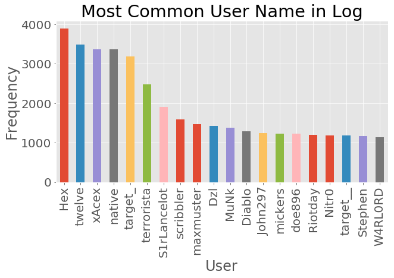

```python
plt.rcParams['font.size'] = 20
fig = plt.figure(figsize=(10,5))
ax = fig.add_subplot(1,1,1)
ax.set_title('Most Common User Name in Log')
ax.set_xlabel("User")
ax.set_ylabel("Frequency")
df['Name'].value_counts()[:20].plot(kind='bar',ax=ax)
plt.show()
```

#### So we can see most common user is

```
Hex, than twelve, xAcex, native
```

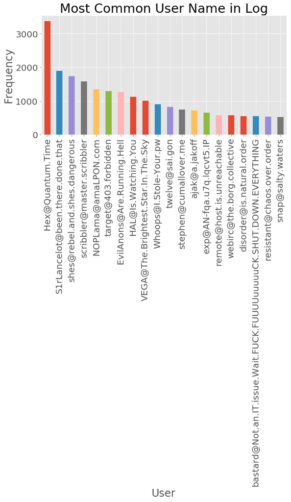

```python
plt.rcParams['font.size'] = 20
fig = plt.figure(figsize=(10,5))
ax = fig.add_subplot(1,1,1)
ax.set_title('Most Common User Name in Log')
ax.set_xlabel("User")
ax.set_ylabel("Frequency")
df['Username'].value_counts()[:20].plot(kind='bar',ax=ax)
plt.show()
```

### Q2. Find the most common words (3 pts)

#### Let's Find Most Common World

```python
f = open('hackers.log',encoding='latin1') # reading log file
data = f.read()
raw_data = data.split() # spliting data from space so that we have word list
```

```python
import pandas as pd # importing necessary libraries for processing
import numpy as np

s = pd.Series(raw_data) # createing a Series Object from string to process it quickly and efficiently
# as well as Pandas series provides us many functionaities as we can group, count or plot data
```

```python
s.value_counts()[:20] # value count willl count each word's repetation than we are slicing to 20 most comman words oly
```

```
-!-            246910
has            230814
<              170074
#hackers       119392
joined         114639
quit           109590
to              41055
a               40354
[Quit:          38620
timeout:        37437
121             37410
seconds]        37227
[Ping           37195
and             35808
the             35491
is              34683
closed]         32785
<+evilbot>      30725
-               29510
[Connection     29238
dtype: int64
```

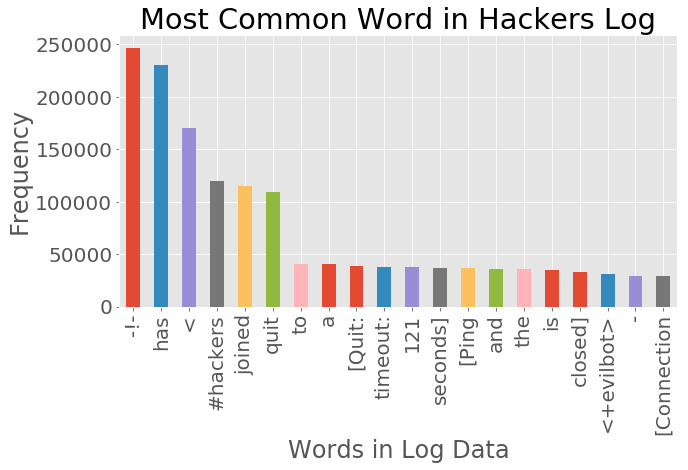

```python
import matplotlib.pyplot as plt
plt.rcParams['font.size'] = 20
fig = plt.figure(figsize=(10,5))
ax = fig.add_subplot(1,1,1)
ax.set_title("Most Common Word in Hackers Log")
ax.set_xlabel("Words in Log Data")
ax.set_ylabel("Frequency")
s.value_counts()[:20].plot(kind='bar',ax=ax) # plotting 20 most comman words
plt.show()
```

### Conclusion

*above figure we can see the most common word is -!- but we don't count it as it has no sense as has,V also doesno't have sense

#### Most Common Word is **#hackers**

#### second most common word is **joined**

#### third most common word is **quit**

*we will not include quit, to, a [Quit as words then

#### timeout is fourth most common word

###### others are seconds, ping, closed, <+evilbot> and [Connection]

### Processing Data without stop words

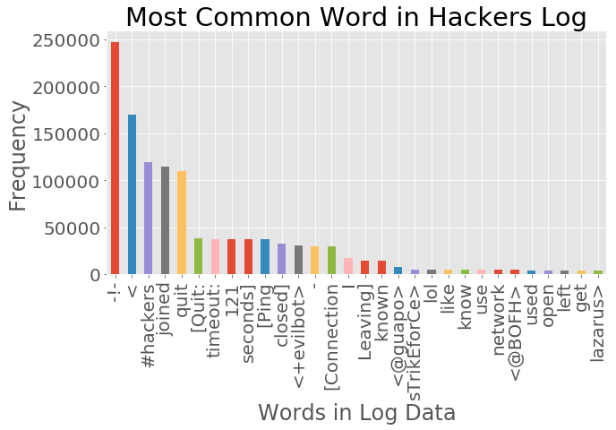

```python
from nltk.corpus import stopwords
import pandas as pd
import matplotlib.pyplot as plt
%matplotlib inline
stop_words = stopwords.words('english')
f = open('hackers.log',encoding='latin')
data = f.read().split()
new_data = pd.Series([ word for word in data if word not in stop_words])
word_freq = new_data.value_counts()
# 30 most Common Words
plt.rcParams['font.size'] = 20
fig = plt.figure(figsize=(10,5))
ax = fig.add_subplot(1,1,1)
ax.set_title("Most Common Word in Hackers Log")
ax.set_xlabel("Words in Log Data")
ax.set_ylabel("Frequency")
word_freq[:30].plot(kind='bar',ax=ax)
plt.show()
```

### Q3. Count the total number of written messages (only those with actual text content) (2 pts).Summarize the users that posted the most messages (2pts)

```python
f = open('hackers.log',encoding='latin1')
data = f.read()
f.close()
print(data[:10000])
```

```
--- Log opened Tue Sep 20 00:01:49 2016
00:01 -!- Guest40341 [AndChat2541@AN-pl0gl1.8e2d.64f9.r226rd.IP] has quit [Quit: Bye]
00:11 -!- peejr [peeejr@AN-sru.3ib.ec0efc.IP] has joined #hackers
00:14 -!- Gilgamesh [Gilgamesh@AN-nkf.mv0.se355c.IP] has joined #hackers
00:15 -!- _CyBruh_ [-Cybruh@AN-gm6.oj9.rj1tv4.IP] has quit [Quit: Leaving]
00:20 -!- peejr [peeejr@AN-sru.3ib.ec0efc.IP] has quit [Quit: Leaving]
00:25 < ice231> anyone good with exploiting cisco asa with extrabacon?
00:27 < ice231> we need help with an op but were stuck at this one part
00:27 -!- Bobseviltwin [steven@stupid.hunkey.monkey] has quit [Ping timeout: 121 seconds]
00:30 -!- Gilgamesh [Gilgamesh@AN-nkf.mv0.se355c.IP] has quit [Quit: Leaving]
00:30 -!- peejr [peeejr@AN-sru.3ib.ec0efc.IP] has joined #hackers
00:34 -!- peejr [peeejr@AN-sru.3ib.ec0efc.IP] has quit [Quit: Leaving]
00:34 -!- peejr [peeejr@AN-sru.3ib.ec0efc.IP] has joined #hackers
00:35 -!- Anonymous5 [Anonymous5@AN-tu4.e85.r2ddjo.IP] has joined #hackers
00:35 -!- lazyNitr0 [resistant@AN-kjb.6km.8lhfko.IP] has quit [Quit: Never quit!!]
00:35 -!- peejr [peeejr@AN-sru.3ib.ec0efc.IP] has quit [Quit: Leaving]
00:36 -!- peejr [peeejr@AN-sru.3ib.ec0efc.IP] has joined #hackers
00:36 -!- Nitr0 [resistant@AN-kjb.6km.8lhfko.IP] has joined #hackers
00:41 -!- peejr [peeejr@AN-sru.3ib.ec0efc.IP] has quit [Quit: Leaving]
00:44 -!- SiliconAlchemist [anon@technoalchemy.com] has left #hackers []
00:45 -!- Anonymous5 [Anonymous5@AN-tu4.e85.r2ddjo.IP] has quit [Ping timeout: 121 seconds]
00:47 -!- ice231 [ice231@AN-8ak.iq1.hl67p8.IP] has quit [Ping timeout: 121 seconds]
00:48 -!- keddy [lulzface@k.e.d.d.y] has quit [Connection closed]
00:50 -!- ice231 [ice231@AN-6ks.fag.lh60mn.IP] has joined #hackers
01:08 -!- S0ldierF0rever [S0ldierF0re@AN-5ms.4a0.9sk9lp.IP] has quit [Ping timeout: 121 seconds]
01:15 -!- HeavenGuard [webirc@AN-o8o.sb7.2n2b0e.IP] has joined #hackers
01:17 < HeavenGuard> hello?
01:17 <+nemecy> hi
01:22 -!- lulzdrone [lulz@drone.incoming.pew.pews] has joined #hackers
01:23 < ice231> hi
01:25 -!- Guest31645 [androirc@AN-l8e.7dp.8hdu3q.IP] has joined #hackers
01:29 -!- dedocne [Unknown@AN-6mk.97v.o0pdt6.IP] has quit [Quit: When 2+2 = You, iPoo, by Apple]
01:30 -!- hellboy [prudent@AN-r5g.h92.dq7njm.IP] has joined #hackers
01:31 -!- hellboy is now known as Guest26312
01:33 -!- Guest31674 [prudent@AN-r5g.h92.dq7njm.IP] has quit [Ping timeout: 121 seconds]
01:37 -!- AndroUser2 [androirc@AN-l8e.7dp.8hdu3q.IP] has joined #hackers
01:37 -!- Guest31645 [androirc@AN-l8e.7dp.8hdu3q.IP] has quit [Connection closed]
01:38 -!- AndroUser2 is now known as Guest25727
01:44 -!- peejr [peeejr@AN-sru.3ib.ec0efc.IP] has joined #hackers
01:45 -!- Guest25727 [androirc@AN-l8e.7dp.8hdu3q.IP] has quit [Connection closed]
```

[output cut: 85 more lines]

```
05:04 -!- S0ldierF0rever [S0ldierF0re@AN-5ms.4a0.9sk9lp.IP] has joined #hackers
05:04 -!- hellboy [prudent@AN-r5g.h92.dq7njm.IP] has joined #hackers
05:05 -!- hellboy is now known as Guest11966
05:06 -!- yetw4t3rm3lon [lion@AN-ki4.fjp.5fmv18.IP] has quit [Connection closed]
05:07 -!- distantcicada [bird@AN-ki4.fjp.5fmv18.IP] has joined #hackers
05:07 -!- gladpuppy [fly@AN-6qn.dnl.0if8mq.IP] has joined #hackers
05:08 -!- distantcicada [bird@AN-ki4.fjp.5fmv18.IP] has quit [Client exited]
05:15 -!- Klaatu [me@AN-7um.cla.rsvtrk.IP] has quit [Connection closed]
05:16 -!- Klaatu [me@AN-7um.cla.rsvtrk.IP] has joined #hackers
05:17 -!- Klaatu_ [me@AN-7um.cla.rsvtrk.IP] has joined #hackers
05:18 -!- Klaatu_ [me@AN-7um.cla.rsvtrk.IP] has quit [Quit: abducted by aliens]
05:28 -!- AnoNewb [AnoNewb@AN-l9k.23k.193g1c.IP] has joined #hackers
05:34 -!- inity13 [inity13@AN-jf7.475.5rba3v.IP] has joined #hackers
05:50 -!- TheMessanger [ShadowMask@AN-lk8.ng2.tvsps7.IP] has joined #hackers
05:57 -!- CyBruh [Cybruh@AN-gm6.oj9.rj1tv4.IP] has quit [Ping t
```

```python
pattern = r"[0-9]{0,2}:[0-9]{0,2}.*<.*>.*"
lines = []
for line in data.split('\n') :
    d = re.findall(pattern,line)
    if d :
        lines.append(d[0])
```

```python
lines[:5000]
```

```
['00:25 < ice231> anyone good with exploiting cisco asa with extrabacon?',
 '00:27 < ice231> we need help with an op but were stuck at this one part',
 '01:17 < HeavenGuard> hello?',
 '01:17 <+nemecy> hi',
 '01:23 < ice231> hi',
 "02:55 < Ctrl> Do any of you know any trusted services that provide offshore dedicated servers in countries like Iran, Russia, China, etc, that won't bend at pressure from LE",
 '02:56 < Ctrl> And take bitcoin obviously ',
 '03:50 < cryptomillz> #tutorials',
 '03:51 < Winston> /join #tutorials',
 '03:51 < Winston> do that cryptomillz ^^^',
 '04:15 < cryptomillz> i cant find tutorials on the list',
 '04:16 < cryptomillz> found it',
 '06:32 < UnknownError> Wat ap my bois',
 '07:23 < Freak> Anyone got a good dork for SQLi?',
 '07:40 < sTrikEforCe> i am a giant drunk dork!',
 '09:09 <+nemecy> hi',
 '09:10 < inity13> o/',
 '10:19 <+nemecy> http://i.imgur.com/PoCjYqQ.png',
 '10:53 < maxmuster> ?',
 '10:53 < maxmuster> why',
 '10:55 < CrazyAtom> cause',
 '11:02 < maxmuster> https://vid.pr0gramm.com/2015/08/28/8a9af1793785d29e.mp4',
 '11:06 < AnoNewb> plz anyone help me hack www.ismoman.com',
 '11:06 < maxmuster> why',
 '11:06 < azorean> again ?',
 '11:06 < azorean> thats the school website no >',
 '11:06 < maxmuster> yes',
 '11:06 < azorean> ?',
 '11:07 < maxmuster> ah',
 '11:07 < LevAnon> hahaahahhaha dude, hit the books and study',
 '11:08 < azorean> if that is the same idian school website who treat bad the students bla bla bla... someone here hacked it already',
 '11:08 < azorean> pretty fast gotta say',
 '11:08 < azorean> lol',
 '11:12 < maxmuster> AnoNewb you need to talk to us',
 '11:46 < maxmuster> love those guys..',
 '11:47 < azorean> lol',
 '11:54 < someone25572> love u too',
 '13:04 < azorean> yyy tas ai ?',
 '13:05 < maxmuster> what?',
 "13:13 < LevAnon> he's speaking spanish",
```

[output cut: 946 more lines]

```
 "20:19 < Bitfuse> first of all let's make a logic",
 '20:19 < North_Star> maybe O.o',
 '20:19 < Bitfuse> The server software is PHP 5.6.16',
 '20:19 < North_Star> .......',
 '20:19 < North_Star> Nobody gave a single fuck .-.',
 "20:19 < Bitfuse> the x-powered-by header is being passed to the reverse proxy. Cloudflare ain't masking that.",
 '20:20 < Bitfuse> second the header of the mailer leaves a symfony footprint',
 '20:20 < Bitfuse> symfony swiftmailer to be exact',
 "20:20 < Bitfuse> so it's some kind of php framework using symfony.",
 '20:21 < Bitfuse> not that hard to discover',
 '20:21 < North_Star> Bitfuse, Sensei. Teach me how do you do that O.o',
 '20:21 < Irishsec> what site u tryng to get into?',
 '20:21 < Bitfuse> I am not trying to get into it lol',
 '20:21 < Bitfuse> Just watching ',
 ...]
```

```python
messages = '\n'.join(lines)
```

```python
len(data.split('\n'))
```

```
478905
```

```python
messages[:1000]
```

```
"00:25 < ice231> anyone good with exploiting cisco asa with extrabacon?\n00:27 < ice231> we need help with an op but were stuck at this one part\n01:17 < HeavenGuard> hello?\n01:17 <+nemecy> hi\n01:23 < ice231> hi\n02:55 < Ctrl> Do any of you know any trusted services that provide offshore dedicated…
```

```python
length = len(messages.split('\n'))
print(length)
```

```
229670
```

## So There are total 229670 messages with actual text Content out of 478905 lines of text available in log file

```python
pat = re.compile('<.*>')
```

```python
k = re.findall(pat,messages)
```

```python
len(k)
```

```
229670
```

```python
s = pd.Series(data=k)
s = s.apply(lambda x:x[1:-1].strip())
```

```python
s.head()
```

```
0         ice231
1         ice231
2    HeavenGuard
3        +nemecy
4         ice231
dtype: object
```

```python
s.tail()
```

```
229665         hypnotic
229666         hypnotic
229667    +Cogitabundus
229668    +Cogitabundus
229669             DeTH
dtype: object
```

[figure not shown]

```python
plt.rcParams['font.size'] = 20
fig = plt.figure(figsize=(10,9))
ax = fig.add_subplot(1,1,1)
plt.title("Top 30 Students who participate most in messages")
plt.xlabel("Students")
plt.ylabel("Frequency")
s = s.apply(lambda x:x[1:-1])
s.value_counts()[:30].plot(kind='bar',ax=ax)
plt.show()
```

## So most of the messages are send by +evilbot than @guapo, sTriKEforCe, @BOFH and other common user who send most messages are lazarus, DeTH, catface, dd and so on ...

## Q.4 Find and rank (by count) words not in an English dictionary (3 pts). This is a simple method that can identify some names of malware tools

```python
import pandas as pd
import numpy as np
df  = pd.read_csv('english_words.csv',sep='\t',header=None)
df.head()
df.drop(1,axis=1,inplace=True)
print(df.shape)
df.head()
```

```
(333333, 1)
```

|  | 0 |
| --- | --- |
| 0 | the |
| 1 | of |
| 2 | and |
| 3 | to |
| 4 | a |

```python
word_list = df.to_dict()[0]
```

```python
english_word = list(word_list.values())
```

```python
import nltk
nltk.download('wordnet')
```

```
True
```

```python
from nltk.corpus import wordnet
import re
from nltk.corpus import stopwords
from nltk.tokenize import word_tokenize

example_sent = "This is a sample sentence, showing off the stop words filtration."

stop_words = set(stopwords.words('english'))


def check_english_word(word):
    word = word.lower()
    if not wordnet.synsets(word):
        #Not an English Word
        p = re.compile(r".*[0-9]{0,2}:[0-9]{0,2}.*")
        p1 = re.compile(r".*-!-.*")
        p2 = re.compile(r".*<|>.*")
        p3 = re.compile(r".*\s.*")
        p4 = re.compile(r"[0-9]*")
        p5 = re.compile(r".*\[|\].*")
        p6 = re.compile(r".*@.*")
        pat = re.findall(p,word)
        pat1 = re.findall(p1,word)
        pat2 = re.findall(p2,word)
        pat3 = re.findall(p3,word)
        pat4 = re.findall(p4,word)
        pat5 = re.findall(p5,word)
        pat6 = re.findall(p6,word)

        if any([pat,pat1,pat2,pat5,pat3]):
            return np.nan
        elif word in stop_words :
            return np.nan
        elif word.isidentifier :
            return word
        else  :
            return np.nan
    else:
        #English Word
        return np.nan
```

```python
str.isidentifier
```

```
<method 'isidentifier' of 'str' objects>
```

```python
f = open('hackers.log',encoding='latin1')
data = f.read()
f.close()
```

```python
data = messages.split('\n')
```

```python
data = ' '.join(data)
```

```python
data = data.split()
```

```python
series = pd.Series(data)
```

```python
no_english_words = series.apply(check_english_word)
```

no_english_words.dropna(inplace=True) no_english_words = no_english_words.apply(lambda word : word if word in english_word else np.nan)

```python
no_english_words.dropna(inplace=True)
```

```python
no_english_words.value_counts()[:1130]
```

```
-              28435
lol             5758
?               3810
im              3207
sql             2791
could           2682
would           2671
perl            2540
dont            2469
i'm             2415
anyone          1895
something       1635
/               1624
nmap            1581
hey             1537
login           1503
-tools          1433
thats           1425
sqlmap          1405
that's          1400
pentesting      1394
wireshark       1362
nikto           1332
aircrack-ng     1317
wordpress       1313
wep             1301
vpn             1299
dsniff          1297
wpscan          1283
,               1276
               ...
lulzsec           25
he'll             25
around?           25
things,           25
wich              25
attack.           25
whoa              25
said.             25
l33t              25
-nikto            25
bsd               25
fine.             25
name,             25
tool.             25
gdb               25
et                25
k@li              25
also.             25
ryt               25
companies,        25
-nipper           25
win10             25
like?             25
fud               25
else?             25
irc,              25
systemd           25
imgur             25
netgear           25
need?             25
Length: 1130, dtype: int64
```

```python
no_english_words.iloc[12]
```

```
'#tutorials'
```

```python
no_english_words.shape
```

```
(340134,)
```

```python
n = no_english_words.apply(lambda x : x if x.strip() not in words else np.nan)
```

```python
p = n.dropna()
```

```python
n.shape
```

```
(340134,)
```

```python
p.shape
```

```
(309052,)
```

```python
pat = '[0-9]*'
s = '    123  '
k = re.match(pat,s)
sum(k.span())
```

```
0
```

```python
non_english = p.apply(lambda word: np.nan if sum((re.match(pat,word.strip())).span()) else word)
```

import nltk nltk.download('words')

```python
import nltk
words = set(nltk.corpus.words.words())
```

```python
'could' in words
```

```
True
```

```python
non_english.dropna(inplace=True)
```

```python
p.shape
```

```
(309052,)
```

```python
non_english.shape
```

```
(301799,)
```

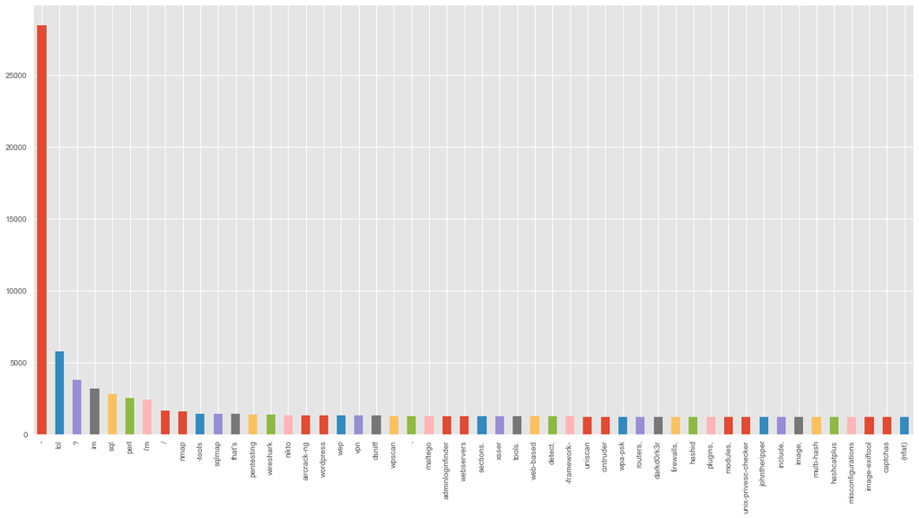

```python
import matplotlib.pyplot as plt
plt.rcParams['font.size'] = 20
plt.style.use('ggplot')
%matplotlib inline
fig = plt.figure(figsize=(20,10))
ax = fig.add_subplot(1,1,1)
non_english.value_counts()[:50].plot(kind='bar',ax=ax)
plt.show()
```

```python
 data  = non_english.value_counts()[:10000]
```

```python
data = list(data.index)
```

```python
data = "\n".join(data)
```

```python
print(data)
```

[output not shown]

[output cut: 9944 more lines]

```
vmware/virtualbox
rasbpi
plzz
"cyber
programmer?
needs,
callign
circles,
researching,
re,
hax0ring
logic'd
term?
blackout?
v1's
```

```python
filter_english = no_english_words.apply(lambda word : word if word.strip().isidentifier() else np.nan)
```

```python
no_english_words.shape
```

```
(340134,)
```

```python
filter_english = filter_english.dropna()
filter_english.shape
```

```
(152287,)
```

```python
filter_english.value_counts()[:20]
```

```
lol           5758
im            3207
sql           2791
could         2682
would         2671
perl          2540
dont          2469
anyone        1895
something     1635
nmap          1581
hey           1537
login         1503
thats         1425
sqlmap        1405
pentesting    1394
wireshark     1362
nikto         1332
wordpress     1313
wep           1301
vpn           1299
dtype: int64
```

```python
import nltk
words = set(nltk.corpus.words.words())

'could' in words
```

```
True
```

```python
final_words = filter_english.apply(lambda x:np.nan if x.strip().lower() in words else x.strip().lower() )
final_words = final_words.dropna()
```

```python
filter_english.shape
```

```
(152287,)
```

```python
final_words.shape
```

```
(121205,)
```

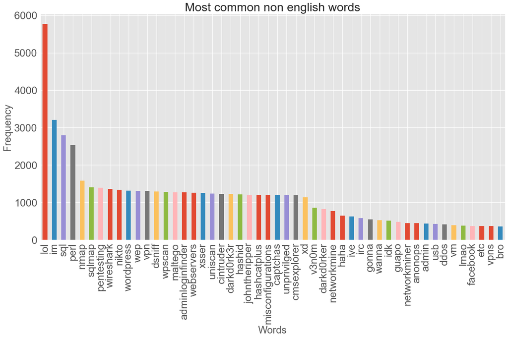

```python
plt.rcParams['font.size'] = 20
fig = plt.figure(figsize=(20,10))
plt.title("Most common non english words")
plt.ylabel('Frequency')
plt.xlabel("Words")
ax = fig.add_subplot(1,1,1)
final_words.value_counts()[:50].plot(ax=ax,kind='bar',fontsize=25)
plt.show()

final_words.to_csv("Most_Common_Non_English_Words.csv")
```

## So by counting non english words we have found some name of malware tools such as nmap, sqlmap, pentesting, wireshark, nikto, dnsiff,wpscan,maltego,adminloginfinder, xser, uniscan, cintruder,